# Homework 6

Nikhil Gupta

2020-02-08 18:58:07

# Setup

```r
library(tswge)
library(tidyverse)
source("../Code/common_functions.R")
```

# Problem 5.1

```r
data("hadley")

hadley %>%
  glimpse()
```

```
##  num [1:160] -0.447 -0.292 -0.294 -0.337 -0.307 -0.321 -0.406 -0.503 -0.513 -0.349 ...
```

## a

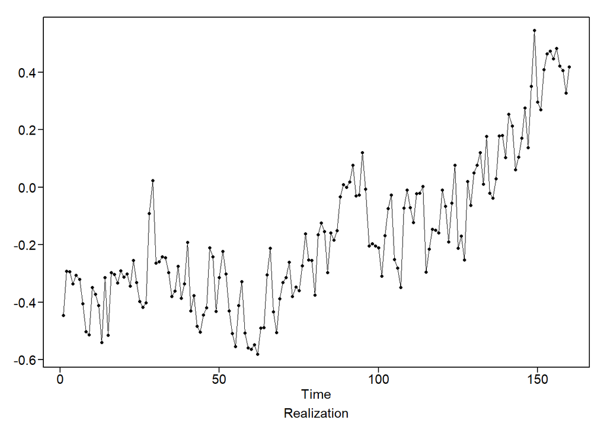

```r
px = plotts.wge(hadley)
```

## b

```r
data = data.frame(temp = hadley)
data = data %>%
  mutate(time = as.numeric(rownames(.)))
str(data)
```

```
## 'data.frame':    160 obs. of  2 variables:
##  $ temp: num  -0.447 -0.292 -0.294 -0.337 -0.307 -0.321 -0.406 -0.503 -0.513 -0.349 ...
##  $ time: num  1 2 3 4 5 6 7 8 9 10 ...
```

```r
model_lm = glm(formula = temp ~ time, data = data)
model_lm
```

```
##
## Call:  glm(formula = temp ~ time, data = data)
##
## Coefficients:
## (Intercept)         time
##   -0.525737     0.004438
##
## Degrees of Freedom: 159 Total (i.e. Null);  158 Residual
## Null Deviance:       10.67
## Residual Deviance: 3.947     AIC: -132.3
```

a_hat = -0.525737 b_hat = 0.0044378

## c

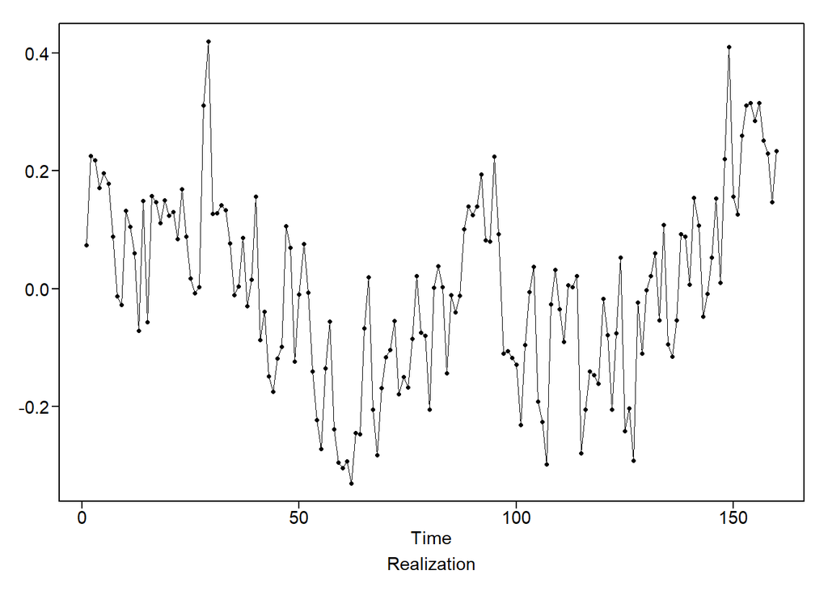

```r
px = plotts.wge(model_lm$residuals)
```

## d

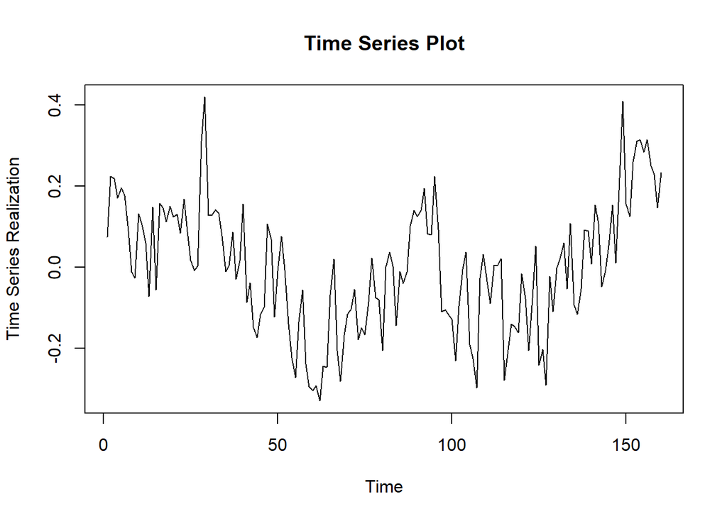

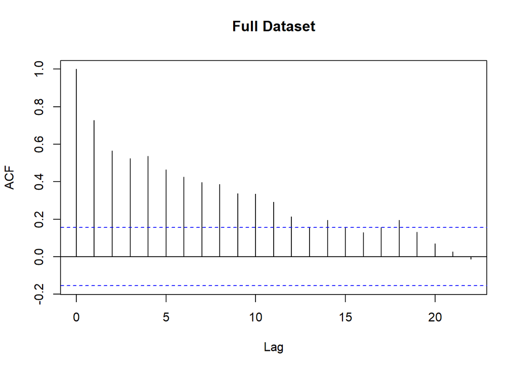

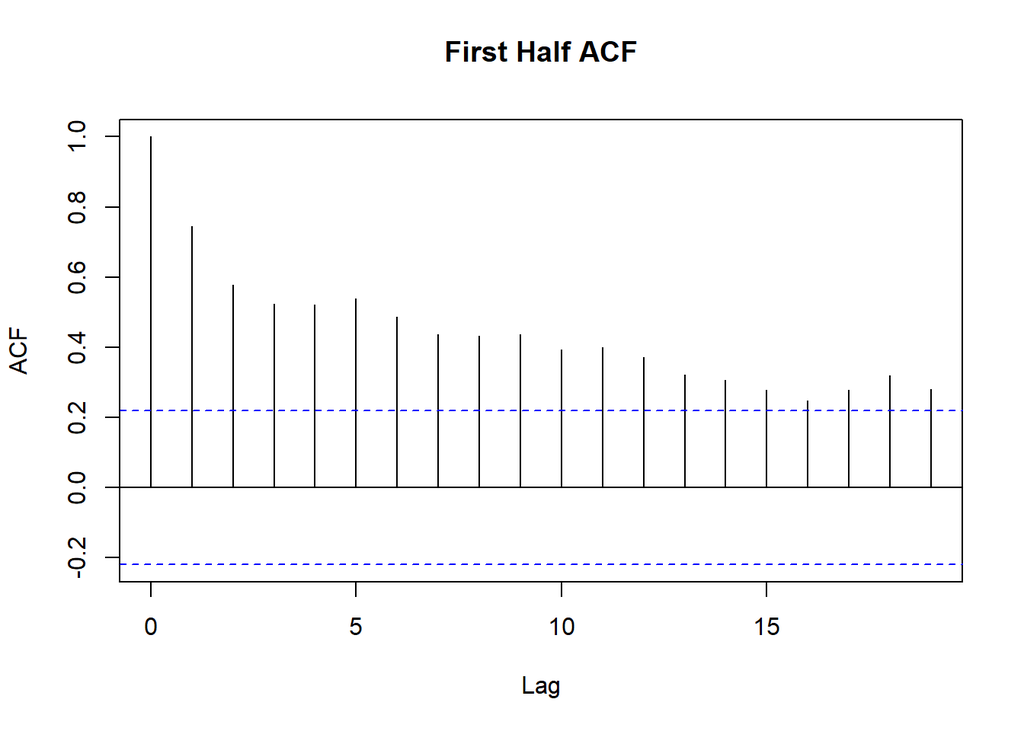

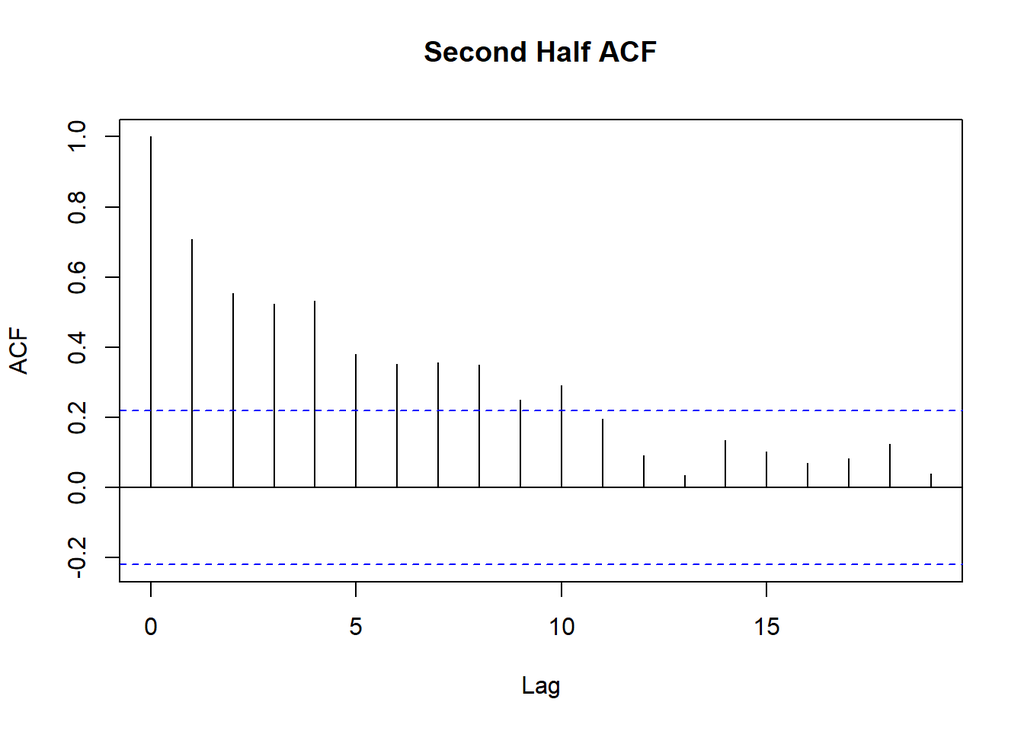

```r
check_stationarity(model_lm$residuals)
```

### Condition 1:

Mean does not depend on time: It is hard to pin point from a single realization. It looks like the mean might be varying with time, but it could just be wandering behavior similar to what is seen in a stationary AR process with real positive root.

### Condition 2:

Variance does not depend on time: Again it is hard to say from just a single realization whether the variance is indepent of time. But given just this dataset, there is no reason to doubt it.

## e

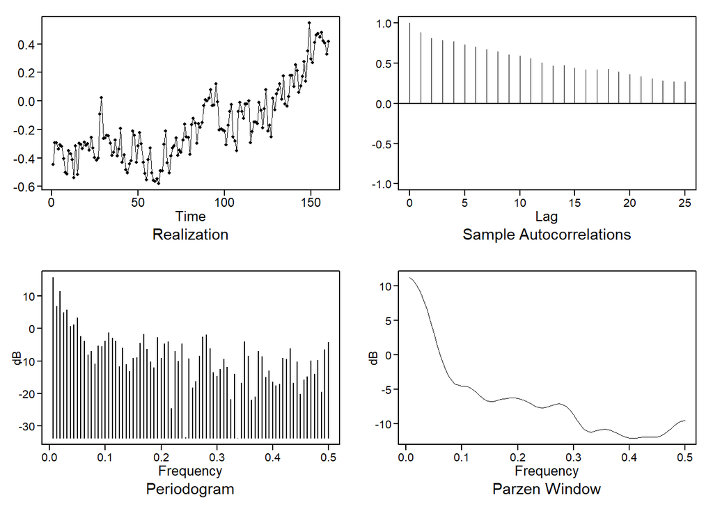

```r
px = plotts.sample.wge(data$temp)
```

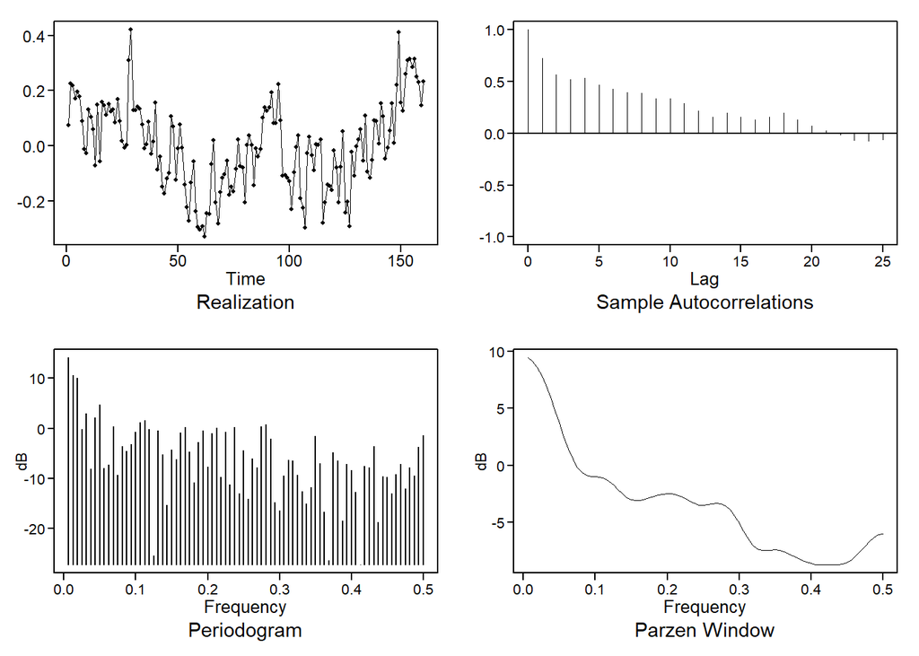

```r
px = plotts.sample.wge(model_lm$residuals)
```

### Original Data

The original data ACF plots show extended autocorrelations pointing to an ARIMA type of model with root at 1. This manifests as wandering behavior in the realizations which can also be seen in the plot.

### Residuals

The residual shows an exponentially decaying ACF, quite similar to what we would expect from a stationary AR process with a real and positive root. This is also reinforced by he Spectral Density plot which shows a peak at 0 (indicative of wandering behavior)